# MODELOS NO SUPERVISADOS - Alvaro Cabrerizo de Garnica

```python
import random
import pandas as pd
import numpy as np
from matplotlib import pyplot as plt
import seaborn as sns
import statistics as st
from sklearn.model_selection import train_test_split
from sklearn.preprocessing import OneHotEncoder
from sklearn.preprocessing import StandardScaler
from sklearn.preprocessing import normalize
from sklearn.decomposition import PCA
from sklearn.cluster import DBSCAN
from sklearn.cluster import KMeans
from sklearn.preprocessing import LabelBinarizer
from sklearn.impute import SimpleImputer
import statistics
import plotly.graph_objects as go
import seaborn as sns
from sklearn.decomposition import KernelPCA
import time
from sklearn.datasets import make_moons
import plotly.io as plot_io
from sklearn import manifold
%matplotlib inline
from sklearn.discriminant_analysis import LinearDiscriminantAnalysis as LDA
from sklearn.ensemble import RandomForestClassifier
from sklearn.metrics import confusion_matrix
from sklearn.metrics import accuracy_score
from numpy.random import rand, seed
from sklearn.neighbors import kneighbors_graph
from sklearn.datasets import make_blobs, make_circles, make_moons
from matplotlib.colors import ListedColormap
from sklearn.cluster import KMeans, SpectralClustering, DBSCAN, AgglomerativeClustering
from sklearn.mixture import GaussianMixture
from sklearn.metrics import adjusted_mutual_info_score
from matplotlib.colors import ListedColormap, LinearSegmentedColormap
from sklearn.metrics import pairwise_distances
from datetime import datetime
from sklearn.manifold import TSNE
from mpl_toolkits.mplot3d import Axes3D

random_state = 100
```

```python
data = pd.read_csv(r'C:\Users\alvar\Downloads\airbnb-listings-extract.csv', sep=';', encoding = "utf8", engine="python")
data.head()
```

|  | ID | Listing Url | Scrape ID | Last Scraped | Name | Summary | Space | Description | Experiences Offered | Neighborhood Overview | ... | Review Scores Communication | Review Scores Location | Review Scores Value | License | Jurisdiction Names | Cancellation Policy | Calculated host listings count | Reviews per Month | Geolocation | Features |
| --- | --- | --- | --- | --- | --- | --- | --- | --- | --- | --- | --- | --- | --- | --- | --- | --- | --- | --- | --- | --- | --- |
| 0 | 11210388 | https://www.airbnb.com/rooms/11210388 | 20170306202425 | 2017-03-07 | The Loft-Full Bath-Deck w/View | Loft in the Hill country 12-15 minutes directl... | This loft has a spectacular view of the hills ... | Loft in the Hill country 12-15 minutes directl... | none | This neighborhood is located in the hills west... | ... | 10.0 | 10.0 | 10.0 | NaN | NaN | moderate | 1.0 | 3.50 | 30.3373609355,-97.8632766782 | Host Is Superhost,Host Has Profile Pic,Host Id... |
| 1 | 17471131 | https://www.airbnb.com/rooms/17471131 | 20170407214050 | 2017-04-08 | Claris I, Friendly Rentals | This apartment has: 1 double bed, 1 double sof... | This apartment has: 1 double bed, 1 double sof... | This apartment has: 1 double bed, 1 double sof... | none | Plaza Cataluña Catalonia Square is the large... | ... | 10.0 | 8.0 | 10.0 | HUTB-006721 | NaN | super_strict_30 | 106.0 | 0.86 | 41.3896829422,2.17262543017 | Host Has Profile Pic,Requires License,Instant ... |
| 2 | 17584891 | https://www.airbnb.com/rooms/17584891 | 20170407214050 | 2017-04-08 | Style Terrace Red, Friendly Rentals | This apartment has: 1 double bed, 1 double sof... | This apartment has: 1 double bed, 1 double sof... | This apartment has: 1 double bed, 1 double sof... | none | Plaza Cataluña Catalonia Square is the large... | ... | NaN | NaN | NaN | HUTB-007527 | NaN | super_strict_30 | 106.0 | NaN | 41.3930345489,2.16217327868 | Host Has Profile Pic,Requires License,Instant ... |
| 3 | 5398030 | https://www.airbnb.com/rooms/5398030 | 20170407214050 | 2017-04-08 | Picasso Suite 1.4 Paseo de Gracia | Live like a local in Barcelona's most chic dis... | You wake up to the sun rising over Barcelona's... | Live like a local in Barcelona's most chic dis... | none | We're right in the heart of the chic L'Eixampl... | ... | 10.0 | 10.0 | 9.0 | NaN | NaN | strict | 24.0 | 1.09 | 41.3969668101,2.1674178103 | Host Has Profile Pic,Host Identity Verified,Re... |
| 4 | 18104606 | https://www.airbnb.com/rooms/18104606 | 20170407214050 | 2017-04-08 | Smart City Centre Apartment II | Unique apartment in vibrant neighborhoods, car... | License: HUTB-005313 Charming apartment, locat... | Unique apartment in vibrant neighborhoods, car... | none | NaN | ... | NaN | NaN | NaN | NaN | NaN | flexible | 92.0 | NaN | 41.3886851936,2.15514963616 | Host Has Profile Pic,Host Identity Verified,Is... |

5 rows × 89 columns

### Lo primero tras importar el dataset es hacer una pequeña transformacion y un pequeño análisis del mismo en el cual veré como están configurados los datos, el tratamiento a NAs, IDs y demás aspectos de interés para que no interfieran en los resultados posteriores.

```python
data.shape
```

```
(14780, 89)
```

#### Tratamiento de las fechas del dataset

En el dataset presentado se observan varias fechas diferentes, que voy a tratar aunque aún no se con certeza si van a aportar información relevante a los modelos.

```python
fecha_actual=np.datetime64('today')
fecha_actual
```

```
numpy.datetime64('2022-06-16')
```

```python
data["First Review"]=pd.to_datetime(data["First Review"], format='%Y-%m-%d')
data['Last Review']=pd.to_datetime(data['Last Review'], format='%Y-%m-%d')

data['Days Between First and Last'] = (data['Last Review'] - data['First Review']).dt.days
```

```python
data['Host Since total days'] = fecha_actual
data[['Host Since','Host Since total days']] = data[['Host Since','Host Since total days']].apply(pd.to_datetime)
data['Host Since total days'] = (data['Host Since total days'] - data['Host Since']).dt.days
```

Para los diferentes casos considero que lo ideal es pasar las fechas a días valiéndome de la fecha actual para calcular la diferencia en días. También creo una nueva variable "Days Between First and Last" para expresar en días la diferencia entre la primera y la última valoración de cada establecimiento.

#### Tratamiento de limpieza del dataset

```python
cat_features = (data.dtypes[data.dtypes == 'object']
                .index.to_list())
num_features = (data.dtypes[data.dtypes != 'object']
                .index.to_list())
```

El proceso de tratamiento de datos lo he basado en la uniquicidad de cada variable, de esta manera se sabrá si puede aportar al modelo. Que haya muchos valores únicos categóricos en el modelo, aporta más complejidad y a su vez una menor calidad al modelo ya que las posibilidades son mas altas y hay menos casos. Esto no se aplica a los valores numéricos.

```python
data[cat_features].columns
```

```
Index(['Listing Url', 'Last Scraped', 'Name', 'Summary', 'Space',
       'Description', 'Experiences Offered', 'Neighborhood Overview', 'Notes',
       'Transit', 'Access', 'Interaction', 'House Rules', 'Thumbnail Url',
       'Medium Url', 'Picture Url', 'XL Picture Url', 'Host URL', 'Host Name',
       'Host Location', 'Host About', 'Host Response Time',
       'Host Acceptance Rate', 'Host Thumbnail Url', 'Host Picture Url',
       'Host Neighbourhood', 'Host Verifications', 'Street', 'Neighbourhood',
       'Neighbourhood Cleansed', 'Neighbourhood Group Cleansed', 'City',
       'State', 'Zipcode', 'Market', 'Smart Location', 'Country Code',
       'Country', 'Property Type', 'Room Type', 'Bed Type', 'Amenities',
       'Calendar Updated', 'Has Availability', 'Calendar last Scraped',
       'License', 'Jurisdiction Names', 'Cancellation Policy', 'Geolocation',
       'Features'],
      dtype='object')
```

Quito todas las variables categoricas que aparentemente no indican ningun tipo de caracteristica que aporte informacion muy relevante al modelo. Ya sea porque aportan información repetida o porque solamente aportan información identificativa que no informativa.

```python
data = data.drop(columns=['Listing Url', 'Last Scraped', 'Name', 'Summary', 'Space', 'Description', "Neighborhood Overview",
                          "Notes", "Transit", 'Access', "Interaction", "House Rules", 'Thumbnail Url', 'Medium Url',
                          'Picture Url',  'XL Picture Url', "Host URL", "Host Name", 'Host Since', "Host Location",
                          "Host About", "Host Thumbnail Url", "Host Picture Url", "Host Neighbourhood", "Host Verifications",
                          "Street", "Neighbourhood", "Neighbourhood Cleansed", "Calendar Updated", "Calendar last Scraped",
                          'First Review', 'Last Review', "License","Jurisdiction Names", 'Geolocation', "Features" ])
data.head()
```

|  | ID | Scrape ID | Experiences Offered | Host ID | Host Response Time | Host Response Rate | Host Acceptance Rate | Host Listings Count | Host Total Listings Count | Neighbourhood Group Cleansed | ... | Review Scores Cleanliness | Review Scores Checkin | Review Scores Communication | Review Scores Location | Review Scores Value | Cancellation Policy | Calculated host listings count | Reviews per Month | Days Between First and Last | Host Since total days |
| --- | --- | --- | --- | --- | --- | --- | --- | --- | --- | --- | --- | --- | --- | --- | --- | --- | --- | --- | --- | --- | --- |
| 0 | 11210388 | 20170306202425 | none | 58386783 | within an hour | 100.0 | NaN | 1.0 | 1.0 | NaN | ... | 10.0 | 10.0 | 10.0 | 10.0 | 10.0 | moderate | 1.0 | 3.50 | 350.0 | 2317.0 |
| 1 | 17471131 | 20170407214050 | none | 102947901 | within an hour | 100.0 | NaN | 162.0 | 162.0 | Eixample | ... | 10.0 | 10.0 | 10.0 | 8.0 | 10.0 | super_strict_30 | 106.0 | 0.86 | 0.0 | 2046.0 |
| 2 | 17584891 | 20170407214050 | none | 102947901 | within an hour | 100.0 | NaN | 162.0 | 162.0 | Eixample | ... | NaN | NaN | NaN | NaN | NaN | super_strict_30 | 106.0 | NaN | NaN | 2046.0 |
| 3 | 5398030 | 20170407214050 | none | 131794 | within an hour | 100.0 | NaN | 27.0 | 27.0 | Eixample | ... | 9.0 | 10.0 | 10.0 | 10.0 | 9.0 | strict | 24.0 | 1.09 | 319.0 | 4405.0 |
| 4 | 18104606 | 20170407214050 | none | 54310958 | within an hour | 99.0 | NaN | 207.0 | 207.0 | Eixample | ... | NaN | NaN | NaN | NaN | NaN | flexible | 92.0 | NaN | NaN | 2347.0 |

5 rows × 55 columns

Seguidamente paso a revisar los datos numéricos.

```python
cat_features = (data.dtypes[data.dtypes == 'object']
                .index.to_list())
num_features = (data.dtypes[data.dtypes != 'object']
                .index.to_list())
```

```python
data[num_features].columns
```

```
Index(['ID', 'Scrape ID', 'Host ID', 'Host Response Rate',
       'Host Listings Count', 'Host Total Listings Count', 'Latitude',
       'Longitude', 'Accommodates', 'Bathrooms', 'Bedrooms', 'Beds',
       'Square Feet', 'Price', 'Weekly Price', 'Monthly Price',
       'Security Deposit', 'Cleaning Fee', 'Guests Included', 'Extra People',
       'Minimum Nights', 'Maximum Nights', 'Availability 30',
       'Availability 60', 'Availability 90', 'Availability 365',
       'Number of Reviews', 'Review Scores Rating', 'Review Scores Accuracy',
       'Review Scores Cleanliness', 'Review Scores Checkin',
       'Review Scores Communication', 'Review Scores Location',
       'Review Scores Value', 'Calculated host listings count',
       'Reviews per Month', 'Days Between First and Last',
       'Host Since total days'],
      dtype='object')
```

```python
data[num_features].nunique()
```

```
ID                                14780
Scrape ID                            38
Host ID                            8935
Host Response Rate                   70
Host Listings Count                  56
Host Total Listings Count            56
Latitude                          14780
Longitude                         14780
Accommodates                         16
Bathrooms                            17
Bedrooms                             10
Beds                                 16
Square Feet                         103
Price                               370
Weekly Price                        388
Monthly Price                       586
Security Deposit                    124
Cleaning Fee                        111
Guests Included                      15
Extra People                         68
Minimum Nights                       43
Maximum Nights                      173
Availability 30                      31
Availability 60                      61
Availability 90                      91
Availability 365                    366
Number of Reviews                   263
Review Scores Rating                 54
Review Scores Accuracy                9
Review Scores Cleanliness             9
Review Scores Checkin                 9
Review Scores Communication           8
Review Scores Location                8
Review Scores Value                   9
Calculated host listings count       45
Reviews per Month                   841
Days Between First and Last        1663
Host Since total days              2116
dtype: int64
```

#### Tratamiento de IDs

A simple vista se puede ver que muchas variables no sirven, unas porque son ID, números de identificación, otras porque son coordenadas y por ultimo "Host Total Listings Count" que está repetida.

Tambien utilizaré el ID general como index del dataset.

```python
data = data.set_index(['ID'])
```

```python
data = data.drop(columns=['Scrape ID',"Host ID", 'Latitude', 'Longitude', "Host Total Listings Count",])
```

```python
cat_features = (data.dtypes[data.dtypes == 'object']
                .index.to_list())
num_features = (data.dtypes[data.dtypes != 'object']
                .index.to_list())
```

Con los datos restantes se vuelve a mostrar la uniquicidad y continuo con el proceso de filtrado de aquellas variables menos significativas

```python
data[cat_features].columns
```

```
Index(['Experiences Offered', 'Host Response Time', 'Host Acceptance Rate',
       'Neighbourhood Group Cleansed', 'City', 'State', 'Zipcode', 'Market',
       'Smart Location', 'Country Code', 'Country', 'Property Type',
       'Room Type', 'Bed Type', 'Amenities', 'Has Availability',
       'Cancellation Policy'],
      dtype='object')
```

```python
data[cat_features].nunique()
```

```
Experiences Offered                 5
Host Response Time                  4
Host Acceptance Rate               12
Neighbourhood Group Cleansed       49
City                              246
State                             102
Zipcode                           619
Market                             43
Smart Location                    257
Country Code                       18
Country                            17
Property Type                      22
Room Type                           3
Bed Type                            5
Amenities                       12379
Has Availability                    1
Cancellation Policy                 8
dtype: int64
```

```python
data = data.drop(columns=['Host Acceptance Rate',"Neighbourhood Group Cleansed", 'City', 'State', "Zipcode",'Smart Location','Market','Country Code','Country','Property Type','Amenities'])
```

Se procede al drop de las variables categóricas con mucha variedad de valores y se vuelven a ajustar las listas

```python
cat_features = (data.dtypes[data.dtypes == 'object']
                .index.to_list())
num_features = (data.dtypes[data.dtypes != 'object']
                .index.to_list())
```

#### Tratamiento de NAs

Respecto a los NAs se observa como existe una gran cantidad de ellos en el dataset, por lo que la solución no pasa por eliminarlos. Sino que se deben tratar de manera diferente según sean en las columnas categóricas o numéricas.

En las variables categóricas se sustituyen por NO VALUE.

Mientras que en las numéricas se establece una medida de corte donde las variables con un 25% de contenido mayor de NA's, serán sutituidas por un valor fijo, y si contienen un valor 25% menor de NA's, serán sustituidos por la media de su variables.

```python
100*data[cat_features].isna().sum()/data[cat_features].shape[0]
```

```
Experiences Offered     0.000000
Host Response Time     12.848444
Room Type               0.000000
Bed Type                0.000000
Has Availability       99.918809
Cancellation Policy     0.000000
dtype: float64
```

```python
data[cat_features] = data[cat_features].fillna('NO VALUE')
```

Y rellenamos los valores NA's con un valor categorico conjunto

De la misma manera, lo mismo ocurre con las variables numéricas, lo primero es conocer el % de cada variable representada por NAs.

En función de ese porcentaje decido tomar una decisión, si este es mayor que 25% decido sustituir los valores de NA por un valor numérico fijo muy característico (-99) para poder identificarlos más adelante cuando obtenga resultados. Si el porcentaje es menor que 25% decido que la mejor opción para no descuadrar mucho los datos e interferir en los resultados es sustituir los NAs por el valor de la media del resto de valores de cada variable.

```python
100*data[num_features].isna().sum()/data[num_features].shape[0]
```

```
Host Response Rate                12.848444
Host Listings Count                0.020298
Accommodates                       0.000000
Bathrooms                          0.372124
Bedrooms                           0.169147
Beds                               0.331529
Square Feet                       95.953992
Price                              0.115020
Weekly Price                      75.710419
Monthly Price                     75.906631
Security Deposit                  57.672530
Cleaning Fee                      41.224628
Guests Included                    0.000000
Extra People                       0.000000
Minimum Nights                     0.000000
Maximum Nights                     0.000000
Availability 30                    0.000000
Availability 60                    0.000000
Availability 90                    0.000000
Availability 365                   0.000000
Number of Reviews                  0.000000
Review Scores Rating              22.354533
Review Scores Accuracy            22.503383
Review Scores Cleanliness         22.462788
Review Scores Checkin             22.577808
Review Scores Communication       22.462788
Review Scores Location            22.598106
Review Scores Value               22.604871
Calculated host listings count     0.027064
Reviews per Month                 21.393775
Days Between First and Last       21.400541
Host Since total days              0.020298
dtype: float64
```

```python
data['Host Response Rate'] = data['Host Response Rate'].fillna(value = data['Host Response Rate'].mean())
data['Host Listings Count'] = data['Host Listings Count'].fillna(value = data['Host Listings Count'].mean())
data['Bathrooms'] = data['Bathrooms'].fillna(value = data['Bathrooms'].mean())
data['Bedrooms'] = data['Bedrooms'].fillna(value = data['Bedrooms'].mean())
data['Beds'] = data['Beds'].fillna(value = data['Beds'].mean())
data['Price'] = data['Price'].fillna(value = data['Price'].mean())
data['Review Scores Rating'] = data['Review Scores Rating'].fillna(value = data['Review Scores Rating'].mean())
data['Review Scores Accuracy'] = data['Review Scores Accuracy'].fillna(value = data['Review Scores Accuracy'].mean())
data['Review Scores Cleanliness'] = data['Review Scores Cleanliness'].fillna(value = data['Review Scores Cleanliness'].mean())
data['Review Scores Checkin'] = data['Review Scores Checkin'].fillna(value = data['Review Scores Checkin'].mean())
data['Review Scores Communication'] = data['Review Scores Communication'].fillna(value = data['Review Scores Communication'].mean())
data['Review Scores Location'] = data['Review Scores Location'].fillna(value = data['Review Scores Location'].mean())
data['Review Scores Value'] = data['Review Scores Value'].fillna(value = data['Review Scores Value'].mean())
data['Calculated host listings count'] = data['Calculated host listings count'].fillna(value = data['Calculated host listings count'].mean())
data['Reviews per Month'] = data['Reviews per Month'].fillna(value = data['Reviews per Month'].mean())

data['Square Feet'] = data['Square Feet'].fillna(-99)
data['Weekly Price'] = data['Weekly Price'].fillna(-99)
data['Monthly Price'] = data['Monthly Price'].fillna(-99)
data['Security Deposit'] = data['Security Deposit'].fillna(-99)
data['Cleaning Fee'] = data['Cleaning Fee'].fillna(-99)
```

```python
100*data.isna().sum()/data.shape[0]
```

```
Experiences Offered                0.000000
Host Response Time                 0.000000
Host Response Rate                 0.000000
Host Listings Count                0.000000
Room Type                          0.000000
Accommodates                       0.000000
Bathrooms                          0.000000
Bedrooms                           0.000000
Beds                               0.000000
Bed Type                           0.000000
Square Feet                        0.000000
Price                              0.000000
Weekly Price                       0.000000
Monthly Price                      0.000000
Security Deposit                   0.000000
Cleaning Fee                       0.000000
Guests Included                    0.000000
Extra People                       0.000000
Minimum Nights                     0.000000
Maximum Nights                     0.000000
Has Availability                   0.000000
Availability 30                    0.000000
Availability 60                    0.000000
Availability 90                    0.000000
Availability 365                   0.000000
Number of Reviews                  0.000000
Review Scores Rating               0.000000
Review Scores Accuracy             0.000000
Review Scores Cleanliness          0.000000
Review Scores Checkin              0.000000
Review Scores Communication        0.000000
Review Scores Location             0.000000
Review Scores Value                0.000000
Cancellation Policy                0.000000
Calculated host listings count     0.000000
Reviews per Month                  0.000000
Days Between First and Last       21.400541
Host Since total days              0.020298
dtype: float64
```

#### Limpieza según correlación de la variable objetivo Precio

Tras el tratamiento de los datos se procede con un pequeño análisis del contenido de los datos, más con una finalidad de observación de como funciona el dataset que de otra cosa.

Basado en las preguntas propuestas para esta práctica, decido observar como se relacionan las variables entre sí, pero en especial la variable Price que es sobre la cual se piden estimaciones en la pregunta 3 de esta práctica.

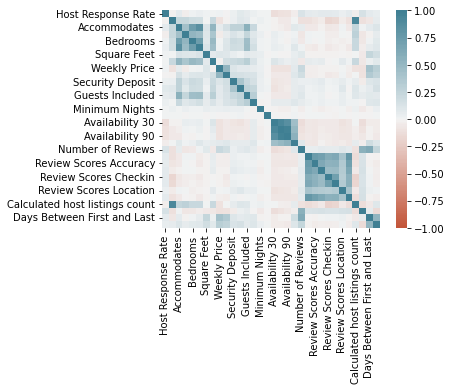

```python
corr = data.corr()
ax = sns.heatmap(
    corr,
    vmin=-1, vmax=1, center=0,
    cmap=sns.diverging_palette(20, 220, n=200),
    square=True
)
```

Es destacable la poca correlación existente entre el ratio de respuesta de los anfitriones (Host response rate) y la disponibilidad tanto a 30 como a 90 días (Availabibity 30 & Availability 90). Lo que indica que cuanto mayor es el ratio de respuesta del anfitrión del Airbnb, menor es la disponibilidad. Probablemente pueda deberse a que estos anfitriones tan activos en sus cuentas de Airbnb son probablemente los que más tiempo dedican a sus anuncios en la web y a las fotografías de sus establecimientos y es por ello que sus viviendas suelen contar con menos disponibilidad, al contar con una "mejor pinta" de cara a los clientes que la que pudieran tener otros establecimientos. También una comunicación más constante con el anfitrión genera sensaciones de confianza entre los consumidores frente a timos o estafas, lo cual también puede influir a la baja disponibilidad de esos Airbnbs de anfitriones con un alto ratio de respuesta.

```python
data[data.columns[0:]].corr()['Price'][:]
```

```
Host Response Rate                0.005620
Host Listings Count               0.226423
Accommodates                      0.520879
Bathrooms                         0.384002
Bedrooms                          0.495893
Beds                              0.440383
Square Feet                       0.074827
Price                             1.000000
Weekly Price                     -0.012068
Monthly Price                     0.178781
Security Deposit                  0.198906
Cleaning Fee                      0.231593
Guests Included                   0.300737
Extra People                      0.125151
Minimum Nights                    0.027424
Maximum Nights                    0.001530
Availability 30                   0.110145
Availability 60                   0.068133
Availability 90                   0.035944
Availability 365                  0.061207
Number of Reviews                -0.058535
Review Scores Rating              0.048830
Review Scores Accuracy            0.044411
Review Scores Cleanliness         0.059795
Review Scores Checkin            -0.006126
Review Scores Communication       0.005469
Review Scores Location            0.075201
Review Scores Value               0.012577
Calculated host listings count    0.222108
Reviews per Month                -0.068136
Days Between First and Last       0.030277
Host Since total days             0.080652
Name: Price, dtype: float64
```

Las correlaciones resultantes no se observan altísimas, las mayores son Accommodates (número de estancias en la vivienda) con un 52% y Bedrooms (habitaciones) con un 49,5%.

Respecto a las menores correlaciones encontramos el Number of Reviews y Review Scores Checkin, lo que nos indica que los anfitriones no se fijan demasiado en las valoraciones que reciben a la hora de establecer los diferentes precios diarios a sus viviendas.

Basado en esta información se procede a seguir limpiando los datos quitando aquellas variables con correlaciones negativas o muy bajas. Quedando un dataset resultante de 19 variables, muy apto para trabajar con el.

```python
data = data.drop(columns=['Host Response Rate','Square Feet','Weekly Price','Minimum Nights','Maximum Nights','Availability 60',
                          'Availability 90','Availability 365','Number of Reviews','Review Scores Rating','Review Scores Accuracy',
                          'Review Scores Cleanliness','Review Scores Checkin','Review Scores Communication','Review Scores Location',
                          'Review Scores Value','Reviews per Month','Days Between First and Last','Host Since total days'])

data.shape
```

```
(14780, 19)
```

```python
cat_features = (data.dtypes[data.dtypes == 'object']
                .index.to_list())
num_features = (data.dtypes[data.dtypes != 'object']
                .index.to_list())
```

# 1. Una reducción de dimensiones y visualización de la base de datos, explicando bien cuántas dimensiones se usan, que varianza explicada hay, y cual sería la mejor técnica.

```python
train_data, test_data = train_test_split(data, test_size=0.3, random_state=100)
```

Lo primero que se hace es una normalización de los datos para que los resultados se observen con facilidad y puedan ser calculados los procesos.

Seguido de una división entre conjuntos train y test con una consideración especial a la variable precio.

```python
scaler = StandardScaler()
train_scaler = scaler.fit(train_data[num_features])

datos_scaled = pd.DataFrame(index=train_data[num_features].index, columns=train_data[num_features].columns,
                            data=train_scaler.transform(train_data[num_features]))

datos_scaled.shape
```

```
(10346, 13)
```

```python
x_train, x_test, y_train, y_test = train_test_split(
                                        datos_scaled.drop(columns = "Price"),
                                        datos_scaled['Price'],
                                        random_state = random_state
                                    )
```

Existen varios métodos para la reducción de dimensiones, los que voy a tratar y comparar en esta práctica para conocer cual es la reduccion mas óptima para mi conjunto de datos son PCA, Kernel, T-sne e Inertia (los métodos vistos en clase).

### PCA & KERNEL

Lo primero con el método de PCA es elaborar una gráfica de barras que indica como los diferentes componentes van explicando diferentes porcentajes del total de datos.

Con el objetivo de conocer cuantos componentes son necesarios para explicar un 80%.

```python
from sklearn.decomposition import PCA
from sklearn.pipeline import make_pipeline
from sklearn.preprocessing import StandardScaler
from sklearn.preprocessing import scale
```

```
[0.29496455 0.44918529 0.56521388 0.65681295 0.73368979 0.80735496
 0.86318267 0.91233454 0.95527254 0.98035697 0.99293676 1.        ]
```

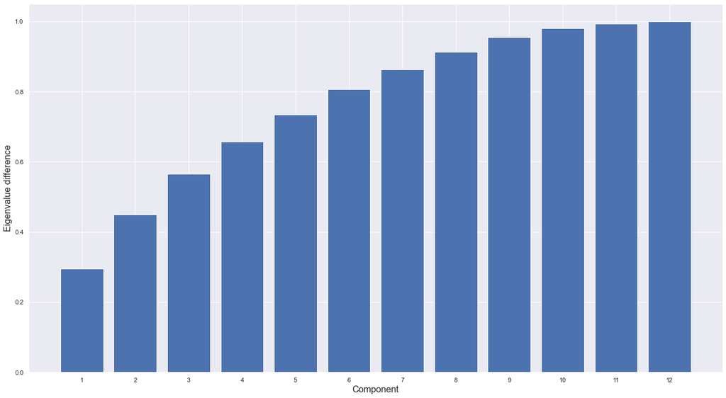

```python
Xcov = np.cov(x_train.T)
l, v = np.linalg.eig(Xcov)
l = np.sort(l)[::-1]
d = l[:l.shape[0] - 1] - l[1:]
cs=np.cumsum(l)/np.sum(l)
sns.set()
print(cs)

fig, ax = plt.subplots(figsize=(22, 12))

ax.bar(np.arange(1, len(cs) + 1, 1), cs)
ax.set_xticks(np.arange(1, len(cs) + 1, 1))
ax.set_xlabel('Component', fontsize=16)
ax.set_ylabel('Eigenvalue difference', fontsize=16)

plt.show()
```

Realizamos el gráfico de barras y podemos observar los diferentes porcentajes que se van explicando tras ir aumentando el número de variables.

El número de componentes principales que explican al menos un 80% es de 6.

Tras conocer el número de componentes principales, se pide conocer el número exacto de la varianza que explican, como se puede observar a continuación es de 80,74%. Lo cual coincide con la gráfica anterior.

```python
pca = PCA(n_components=6)
pcaNum=pca.fit(x_train)
principalComponents = pca.fit_transform(x_train)

print(np.sum(pcaNum.explained_variance_ratio_))
```

```
0.8073549554201832
```

Tras conocer el porcentaje y el número de componentes, se procede con el Kernel, con el objetivo de comparar en 2 gráficas los difentes resultados del PCA y del Kernel para comprobar si nos aportan los mismos resultados o parecidos.

```python
from sklearn.decomposition import KernelPCA

kpca = KernelPCA(14,kernel='rbf')

k_transformed = kpca.fit_transform(x_train)
```

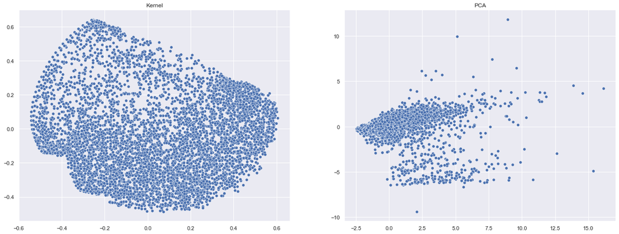

```python
fig, ax = plt.subplots(1,2, figsize=(22,8))

sns.scatterplot(x=k_transformed[:,0],y=k_transformed[:,1], ax=ax[0])
sns.scatterplot(x=principalComponents[:,0],y=principalComponents[:,1], ax=ax[1])

ax[0].set_title('Kernel')
ax[1].set_title('PCA')
```

Como se puede observar, los resultados son bastante diferentes a simplpe vista, pero si nos acercamos nos indican que el número de clusters que parecen identificar son parecidos.

El Kernel nos permite intuir la probable existencia de 2 clusters mientras que el PCA muestra 2 clusters bien marcados y puede que alguno más en la parte derecha del grafico. (Aunque estos últimos pueden tratarse también de valores atípicos, que voy a estudiar a continuación para que no interfieran en los resultados9.

DETECCIÓN DE OUTLIERS

Estos outliers van a ser detectados aplicando sobre la tabla de validación una función para localizar aquellos casos menores a la media - std*3.

En este caso, detectamos 36 posibles outliers.

Una vez detectados estos, necesitamos verificar si de verdad son outliers o no. Es importante destacar que multiplicamos la std*3 puesto que si sólo usasemos las std, estaríamos siendo más estrcitos y por lo tanto saldrían muchos más outliers. En otras palabras, el parámetro que estableceríamos sería mucho más amplio.

```python
logvero=pcaNum.score_samples(x_test)
mean=logvero.mean()
std=logvero.std()
print(mean-std)
print(mean+std)
```

```
-26.81261166589784
-3.58892729268994
```

```python
outliers=x_test.loc[logvero<=mean-(std*3),]
```

Para la verificación de los siguientes outliers, he calculado los quantiles 0.8 y 0.2 de cada variable.

Aquellos casos con un valor por encima del quantile 0.8 o por debajo del quantile 0.2 serán outliers. Una vez establecido este criterio, procedemos a verificarlos.

Variable por variable para cada caso de las 36. Un vez que el posible outlier cumpla la verificación de que sí es outlier para cualquier variable, concluimos que sí que es outlier. En este caso, todos posibles outliers cumplen dicha condición para al menos una variable. Por lo tanto, se procede a eliminarlos.

```python
x_test.quantile([0.8,0.2])
```

|  | Host Listings Count | Accommodates | Bathrooms | Bedrooms | Beds | Monthly Price | Security Deposit | Cleaning Fee | Guests Included | Extra People | Availability 30 | Calculated host listings count |
| --- | --- | --- | --- | --- | --- | --- | --- | --- | --- | --- | --- | --- |
| 0.8 | -0.103629 | 0.342691 | 1.100019 | 0.731355 | 0.602112 | 0.297944 | 0.788523 | 0.765323 | 0.353725 | 0.556815 | 0.854819 | -0.104983 |
| 0.2 | -0.338258 | -0.613222 | -0.433023 | -0.383599 | -0.651895 | -0.395506 | -0.758010 | -1.115414 | -0.496761 | -0.587065 | -0.955438 | -0.361559 |

```python
data_copy = data
```

```python
airbnb_outliers=data
airbnb_outliers['T/F']=data.index.isin([2842881,7713939,8931977,4947067,1010488,176827,10846778,15897830,1575999,
                                               13647790,2307954,12787637,7085486,11162926,1465783,17636420,3402393,
                                               1842370,6012894,6009025,14495975,4378246,15558535,15377196,2744574,1843133,
                                               6791765,1537628,13942955,5923936,6119334,3011110,1044902,1842741,17427098,
                                               8280876])
airbnb_outliers= airbnb_outliers.drop(airbnb_outliers[airbnb_outliers['T/F']==True].index)
```

Tras ello se procede al método T-sne

### T-sne

```python
from sklearn.manifold import TSNE

tsne_1 = TSNE(n_components=2, perplexity= 1000)
tsne_2 = TSNE(n_components=2, perplexity= 100)
tsne_3 = TSNE(n_components=2, perplexity= 10)
tsne_4 = TSNE(n_components=2, perplexity= 1)

data_tsne_1 = tsne_1.fit_transform(datos_scaled)
data_tsne_2 = tsne_2.fit_transform(datos_scaled)
data_tsne_3 = tsne_3.fit_transform(datos_scaled)
data_tsne_4 = tsne_3.fit_transform(datos_scaled)
```

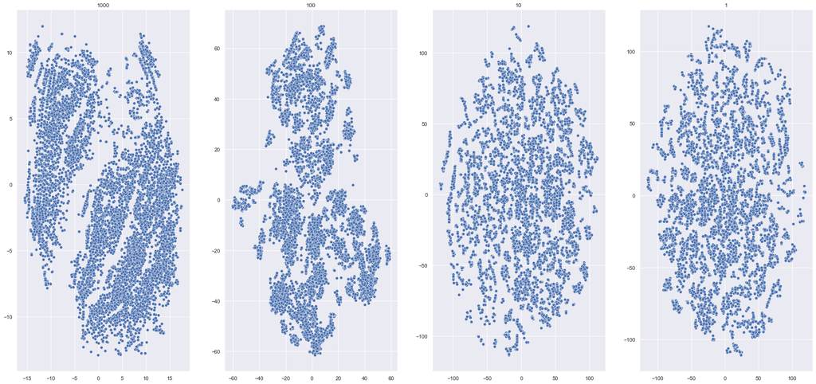

```python
fig, ax = plt.subplots(1,4, figsize=(30,14))
sns.scatterplot(x=data_tsne_1[:,0],
                   y=data_tsne_1[:,1],
                   ax=ax[0])
sns.scatterplot(x=data_tsne_2[:,0],
                   y=data_tsne_2[:,1],
                   ax=ax[1])
sns.scatterplot(x=data_tsne_3[:,0],
                   y=data_tsne_3[:,1],
                   ax=ax[2])
sns.scatterplot(x=data_tsne_4[:,0],
                   y=data_tsne_4[:,1],
                   ax=ax[3])

ax[0].set_title('1000')
ax[1].set_title('100')
ax[2].set_title('10')
ax[3].set_title('1')
plt.show()
```

Tras realizar un T-sne como análisis exploratorio. Se puede apreciar que o bien hay dos clusters o bien a medida que la perplejidad baja, los clusters aumentan.

El número de clusters con perplejidad alta (1000) coincide con los resultados anteriores de PCA y Kernel ya que se pueden observar 2.

Con el fin de intentar obtener una mejor visualización procedo a realizar el método T-sne de una manera distinta para obtener una sola gráfica e intentar calcular el número de clusters que distingue este método.

```python
x= x_train
tsne = TSNE(n_components=2, verbose=1, random_state=random_state)
z = tsne.fit_transform(x)
z
```

```
[t-SNE] Computing 91 nearest neighbors...
[t-SNE] Indexed 7759 samples in 0.051s...
[t-SNE] Computed neighbors for 7759 samples in 2.970s...
[t-SNE] Computed conditional probabilities for sample 1000 / 7759
[t-SNE] Computed conditional probabilities for sample 2000 / 7759
[t-SNE] Computed conditional probabilities for sample 3000 / 7759
[t-SNE] Computed conditional probabilities for sample 4000 / 7759
[t-SNE] Computed conditional probabilities for sample 5000 / 7759
[t-SNE] Computed conditional probabilities for sample 6000 / 7759
[t-SNE] Computed conditional probabilities for sample 7000 / 7759
[t-SNE] Computed conditional probabilities for sample 7759 / 7759
[t-SNE] Mean sigma: 0.000000
[t-SNE] KL divergence after 250 iterations with early exaggeration: 76.479782
[t-SNE] KL divergence after 1000 iterations: 0.978729
```

```
array([[-20.606373 , -58.8532   ],
       [-21.734045 ,  50.10967  ],
       [  3.9180615,  38.7038   ],
       ...,
       [  8.805667 ,  -6.794996 ],
       [ 56.956944 , -48.40772  ],
       [ -1.3459848,  23.116085 ]], dtype=float32)
```

```
[Text(0.5, 1.0, 'Airbnb data T-SNE projection')]
```

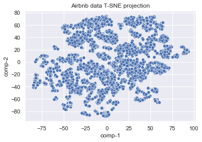

```python
df = pd.DataFrame()
df["comp-1"] = z[:,0]
df["comp-2"] = z[:,1]

sns.scatterplot(x="comp-1", y="comp-2",
                palette=sns.color_palette("hls", 3),
                data=df).set(title="Airbnb data T-SNE projection")
```

Realizamos una proyección del T-SNE para poder visualizar mejor los datos y ya de paso detectar outliers.

Si observamos detenidamente la proyección anterior podemos llegar a distinguir hasta un total de 10 clusters.

Como podemos observar, hay un pequeño grupo de casos situado alrededor de la posición (80,20) en el mapa que se encuentra separado al resto. Por lo tanto, podemos concluir que ese grupo de casos son posiblemente los outliers comentados anteriormente.

#### INERTIA

Tras haber realizado los métodos anteriores, procedo con el último.

Este utiliza el método del codo para identificar el número de clusters.

```python
inertias = []

for i in range(2, 51):
    km = KMeans(n_clusters=i, max_iter=1000, random_state=random_state)
    km.fit(x_train)
    inertias.append(km.inertia_)
```

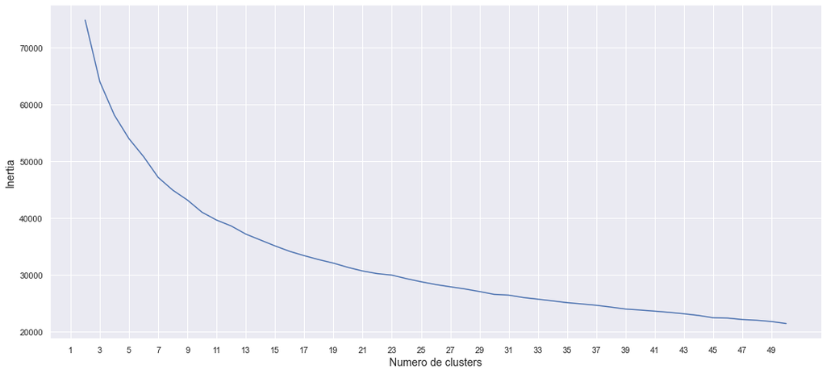

```python
fig, ax = plt.subplots(figsize=(18, 8))

ax.plot(np.arange(2, 51, 1), inertias)
ax.set_xlabel('Numero de clusters', fontsize=14)
ax.set_ylabel('Inertia', fontsize=14)
ax.set_xticks(np.arange(1, 51, 2))

plt.show()
```

La gráfica inertia que se obtiene defiende la existencia de unos 9-11 clusters aproximadamente, según la regla del codo.

No son resultados completamente concluyentes, pero pueden parecerse a los resultados obtenidos en el método anterior del T-sne.

#### CONCLUSIÓN

Como se ha podido comprobar al aplicar las diferentes técnicas de reducción, el PCA nos da una serie de 6 componentes principales que explican un 80.73549% de la varianza.

Mientras que aplicando la técnica del T-sne se puede comprobar que los datos se agrupan en diferentes grupos principales según la perplejidad que tomemos como ejemplo. Me quedo con la cantidad de clusters que obtengo al representar la proyección, que son 10 clusters.

El método de Inertia con la técnica del codo apoya la existencia de entre 9-11 clusters.

También se ha realizado un estudio de los valores atípicos (outliers) y se ha procedido a su identificación mediante tablas (PCA) o gráficas (T-sne).

# 2. Un clustering, utilizando y explicando cual crees que es la mejor técnica.

Para realizar los procesos de clustering, los métodos que voy a utilizar son los vistos en clase y son K-means, Método jerárquico, Density based clustering (DBSCAN) y Gaussian mixture models (GMMs).

#### K-MEANS

Para proceder a los métodos de clustering se rescata el dataset sin normalizar, del cual se eliminan las variables categóricas

```python
data = data.drop(columns=["Experiences Offered","Host Response Time","Room Type","Bed Type","Has Availability",
                         "Cancellation Policy"])

data.shape
```

```
(14780, 14)
```

```python
import statsmodels.api as sm
import matplotlib.font_manager
from matplotlib import style
style.use('ggplot') or plt.style.use('ggplot')

from sklearn.metrics import pairwise_distances
from sklearn.preprocessing import scale

import warnings
warnings.filterwarnings('ignore')
```

```python
X=np.array(data)
y=np.array(data)
```

A la hora de crear la función del método k_means, le ofrecemos la posibilidad de determinar cuantos clusters crea convenientes de entre todas las variables del dataset.

```python
Sum_of_squared_distances = []
K = range(1,15)
for k in K:
    km = KMeans(n_clusters=k)
    km = km.fit(X)
    Sum_of_squared_distances.append(km.inertia_)
```

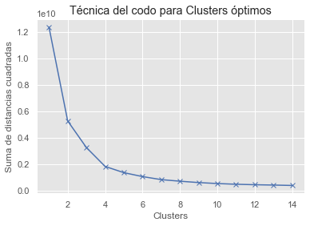

```python
plt.plot(K, Sum_of_squared_distances, 'bx-')
plt.xlabel('Clusters')
plt.ylabel('Suma de distancias cuadradas')
plt.title('Técnica del codo para Clusters óptimos')
plt.show()
```

```python
scaler = StandardScaler()
scaled_features = scaler.fit_transform(data)
```

```python
X=np.array(scaled_features)

kmeans = KMeans(n_clusters=3).fit(X)
```

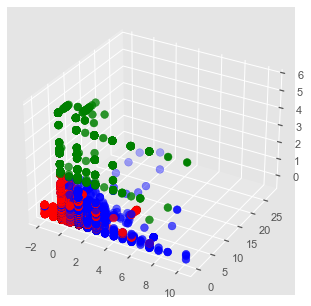

```python
labels = kmeans.predict(X)
C = kmeans.cluster_centers_
colores=['red','green','blue','yellow']
asignar=[]
for row in labels:
    asignar.append(colores[row])

fig = plt.figure()
ax = Axes3D(fig)
ax.scatter(X[:, 2], X[:, 6],  X[:, 12], c=asignar,s=60)
```

Posteriormente, se realiza el k-means con el número de clusters que nos indica y lo ploteamos.

#### MÉTODO JERÁRQUICO

El siguiente método de clusterización utilizado es el método jerárquico.

```python
from sklearn.cluster import AgglomerativeClustering
from scipy.cluster.hierarchy import dendrogram
from sklearn.preprocessing import scale
from sklearn.metrics import silhouette_score
```

Es un proceso de clusterización basado en dendogramas

Para realizar un clustering siguiendo el Método Jerárquico se deben escalar los datos así y tras ello se producen 3 dendogramas según tipops diferentes de "linkage". El linkage es un proceso en el que se tiene que extender el concepto de distancia entre pares de observaciones para que sea aplicable a pares de grupos, cada uno formado por varias observaciones.

Los dendogramas utilizados usan los diferentes tipos de linkage:

- Complete: se calcula la distancia entre todos los posibles pares formados por una observación del cluster A y una del cluster B. La mayor de todas ellas se selecciona como la distancia entre los dos clusters.
- Average: Se calcula la distancia entre todos los posibles pares formados por una observación del cluster A y una del cluster B. El valor promedio de todas ellas se selecciona como la distancia entre los dos clusters.
- Ward: Se trata de un método general. La selección del par de clusters que se combinan en cada paso del agglomerative hierarchical clustering se basa en el valor óptimo de una función objetivo. Se identifican aquellos 2 clusters cuya fusión conlleva menor incremento de la varianza total intra-cluster.

```python
scaler = StandardScaler()
scaled_features = scaler.fit_transform(data)
```

```python
X=np.array(scaled_features)

X_scaled = scale(X)
```

```python
modelo_hclust_complete = AgglomerativeClustering(
                            affinity = 'euclidean',
                            linkage  = 'complete',
                            distance_threshold = 0,
                            n_clusters         = None
                        )
modelo_hclust_complete.fit(X=X_scaled)

modelo_hclust_average = AgglomerativeClustering(
                            affinity = 'euclidean',
                            linkage  = 'average',
                            distance_threshold = 0,
                            n_clusters         = None
                        )
modelo_hclust_average.fit(X=X_scaled)

modelo_hclust_ward = AgglomerativeClustering(
                            affinity = 'euclidean',
                            linkage  = 'ward',
                            distance_threshold = 0,
                            n_clusters         = None
                     )
modelo_hclust_ward.fit(X=X_scaled)
```

```
AgglomerativeClustering(distance_threshold=0, n_clusters=None)
```

Tras ello procedo a la representación en dendogramas de los diferentes modelos según el tipo de linkage, como se ha explicado con anterioridad.

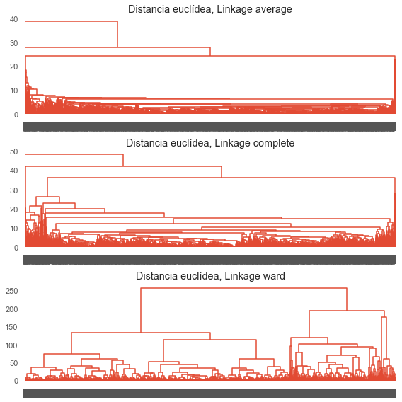

```python
fig, axs = plt.subplots(3, 1, figsize=(8, 8))
plot_dendrogram(modelo_hclust_average, color_threshold=0, ax=axs[0])
axs[0].set_title("Distancia euclídea, Linkage average")
plot_dendrogram(modelo_hclust_complete, color_threshold=0, ax=axs[1])
axs[1].set_title("Distancia euclídea, Linkage complete")
plot_dendrogram(modelo_hclust_ward, color_threshold=0, ax=axs[2])
axs[2].set_title("Distancia euclídea, Linkage ward")
plt.tight_layout();
```

Para conocer el número de clusters que nos indica este método, se hace una línea de corte a una altura de 75 para conocer cuantos clusters hay por debajo pero con el dendograma del linkage Ward, ya que es el que más claro nos indica el número óptimo de clusters que nos indica este método.

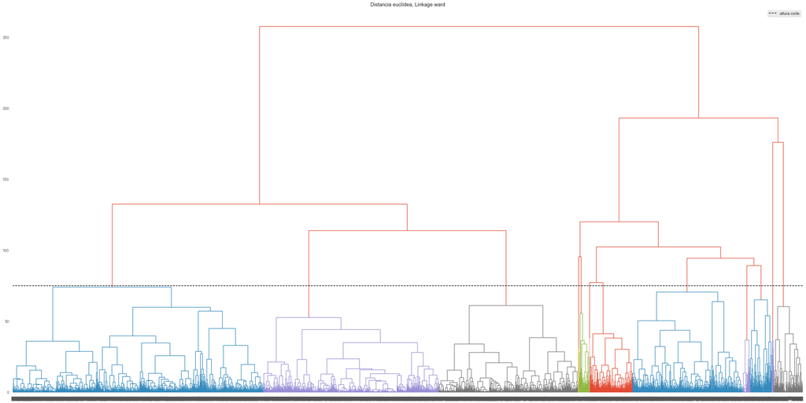

```python
fig, ax = plt.subplots(1, 1, figsize=(40, 20))
altura_corte = 75
plot_dendrogram(modelo_hclust_ward, color_threshold=altura_corte, ax=ax)
ax.set_title("Distancia euclídea, Linkage ward")
ax.axhline(y=altura_corte, c = 'black', linestyle='--', label='altura corte')
ax.legend();
```

Una vez identificado el número óptimo de clusters, se reentrena el modelo indicando el valor óptimo. Por los colores podemos distinguir 9 clusters diferentes.

```python
modelo_hclust_ward = AgglomerativeClustering(
                            affinity = 'euclidean',
                            linkage  = 'ward',
                            n_clusters = 9
                     )
modelo_hclust_ward.fit(X=X_scaled)
```

```
AgglomerativeClustering(n_clusters=9)
```

#### Density based clustering (DBSCAN)

Se trata de una forma de identificar clusters siguiendo el modo intuitivo en el que lo hace el cerebro humano, identificando regiones con alta densidad de observaciones separadas por regiones de baja densidad.

```python
from sklearn.cluster import DBSCAN
from sklearn.preprocessing import scale
from sklearn.metrics import silhouette_score
```

```python
X=np.array(scaled_features)

X_scaled = scale(X)
```

Lo primero que se hace es crear el modelo basándose en la distancia euclídea entre las variables.

```python
modelo_dbscan = DBSCAN(
                    eps          = 0.2,
                    min_samples  = 5,
                    metric       = 'euclidean',
                )

modelo_dbscan.fit(X=X_scaled)
```

```
DBSCAN(eps=0.2)
```

Tras ello se plotean los resultados del método en el que además se indentifican los valores atípicos.

```
No artists with labels found to put in legend.  Note that artists whose label start with an underscore are ignored when legend() is called with no argument.
```

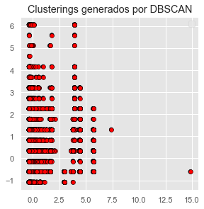

```python
labels = modelo_dbscan.labels_

fig, ax = plt.subplots(1, 1, figsize=(4.5, 4.5))

ax.scatter(
    x = X[:, 0],
    y = X[:, 1],
    c = labels,
    marker    = 'o',
    edgecolor = 'black'
)


ax.scatter(
    x = X[labels == -1, 0],
    y = X[labels == -1, 1],
    c = 'red',
    marker    = 'o',
    edgecolor = 'black',
)

ax.legend()
ax.set_title('Clusterings generados por DBSCAN');
```

Finalmente se calcula el número de clusters según el método DBSCAN y los outliers que identifica este método.

```python
n_clusters = len(set(labels)) - (1 if -1 in labels else 0)
n_noise    = list(labels).count(-1)

print(f'Número de clusters encontrados: {n_clusters}')
print(f'Número de outliers encontrados: {n_noise}')
```

```
Número de clusters encontrados: 129
Número de outliers encontrados: 11697
```

El número de clusters encontrados por este método es exagerado llegando a los 129 por lo que probablemente no estemos ante el método idóneo para el dataset presentado.

#### Gaussian mixture models (GMMs)

```python
from sklearn.mixture import GaussianMixture
from sklearn.preprocessing import scale
from sklearn.metrics import silhouette_score
```

Como en los casos anteriores, lo primero es elaborar el modelo.

Para este caso concreto se asume un número inicial de componentes de 4 para encontrar luego el valor idóneo.

```python
modelo_gmm = GaussianMixture(n_components=4, covariance_type='full', random_state=random_state)
modelo_gmm.fit(X=X)
```

```
GaussianMixture(n_components=4, random_state=100)
```

Lo siguiente en este método es realizar las medias de cada componente del modelo junto con una matriz de covarianzas de cada componente.

```python
modelo_gmm.means_
```

```
array([[ 1.70998950e+00,  3.57990380e-01,  6.02619045e-01,
         3.05656168e-01,  2.60741307e-01,  8.10322291e-01,
        -5.10211765e-02,  1.77091540e-01,  2.91553204e-01,
        -1.16481781e-01, -1.46234291e-01,  6.57280753e-02,
         1.71153108e+00, -4.94132694e-02],
       [-3.19671127e-01, -4.30374072e-01, -2.75492952e-01,
        -3.20036174e-01, -3.80414357e-01, -3.54427842e-01,
        -1.88027020e-01, -2.18823529e-01, -2.24434373e-01,
        -3.15585309e-01, -1.53577604e-01, -2.55895484e-03,
        -3.33139198e-01, -4.94132694e-02],
       [-2.01449688e-01,  4.55509464e-01,  6.69115428e-02,
         3.08384835e-01,  3.81244549e-01,  1.57937841e-01,
         3.00173940e-01,  2.98591647e-01,  2.52494592e-01,
         4.70086248e-01,  2.05224821e-01, -6.17671188e-02,
        -1.88128526e-01, -4.94132694e-02],
       [ 8.31499836e-01,  2.54997966e+00,  2.85700017e+00,
         2.14212369e+00,  3.03883769e+00,  2.15246165e+00,
         8.50168216e-01,  1.51915830e-01,  2.98168497e-01,
         2.24732496e+00,  2.16443189e+00,  6.85777026e-01,
         9.98513975e-01,  2.74849831e+00]])
```

```python
modelo_gmm.covariances_
```

[output not shown]

[output cut: 228 more lines]

[output not shown]

Tras ello se computan las probabilidades de la predicción, cada fila de lo obtenido es una observación y cada columna es la probabilidad de pertenecer a cada uno de los commponentes.

```python
probabilidades = modelo_gmm.predict_proba(X)
probabilidades
```

```
array([[1.12588790e-08, 9.99987977e-01, 1.20113626e-05, 6.92431186e-18],
       [9.99994686e-01, 0.00000000e+00, 0.00000000e+00, 5.31420561e-06],
       [9.99999005e-01, 0.00000000e+00, 0.00000000e+00, 9.94863409e-07],
       ...,
       [5.70296480e-05, 1.12997106e-01, 8.86945864e-01, 4.44921033e-13],
       [8.27141002e-08, 9.99894016e-01, 1.05900900e-04, 5.39705325e-17],
       [3.80880533e-05, 6.44073892e-01, 3.55888020e-01, 1.83837780e-11]])
```

Una vez conocidas las probabilidades se puede proceder a la clasificación, que se trata de asignar a cada variable al componente de mayor probabilidad. Como en el caso de las probabilidades, las filas y las columnas representan lo mismo.

```python
clasificacion = modelo_gmm.predict(X)
clasificacion
```

```
array([1, 0, 0, ..., 2, 1, 1], dtype=int64)
```

Dado que los modelos GMM son modelos probabilísticos, se puede recurrir a métricas como el Akaike information criterion (AIC) o Bayesian information criterion (BIC) para identificar cómo de bien se ajustan los datos observados a modelo creado e identificar el número de clusters.

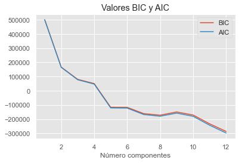

```python
n_components = range(1, 13)
valores_bic = []
valores_aic = []

for i in n_components:
    modelo = GaussianMixture(n_components=i, covariance_type="full")
    modelo = modelo.fit(X)
    valores_bic.append(modelo.bic(X))
    valores_aic.append(modelo.aic(X))

fig, ax = plt.subplots(1, 1, figsize=(6, 3.84))
ax.plot(n_components, valores_bic, label='BIC')
ax.plot(n_components, valores_aic, label='AIC')
ax.set_title("Valores BIC y AIC")
ax.set_xlabel("Número componentes")
ax.legend();
```

```python
print(f"Número óptimo de clusters acorde al BIC: {range(1, 13)[np.argmin(valores_bic)]}")
print(f"Número óptimo de clusters acorde al AIC: {range(1, 13)[np.argmin(valores_aic)]}")
```

```
Número óptimo de clusters acorde al BIC: 12
Número óptimo de clusters acorde al AIC: 12
```

Ambas métricas identifican el 12 como número óptimo de clusters.

#### CONCLUSIÓN

El método jerárquico nos indica un valor de 9 clusters diferentes, el DBSCAN como se ha comentado anteriormente ofrece un resultado atípico con un total de 129 clusters diferentes. Finalmente el método GMM indica que el número óptimo de clusters son 12.

```python
airbnb_clusters=data
airbnb_clusters['airbnb_clusters']=pd.Series(labels, index=airbnb_clusters.index)
airbnb_clusters.head()
```

[output not shown]

# 3. Y asignar un precio estimado a una casa en función del valor medio de todas las casas del cluster al que pertenezca.

Para este ejercicio es extremedamente útil haber añadido un columna extra al dataset con el cluster al que pertenece cada establecimiento.

```python
airbnb_clusters.head()
```

| ID | Host Listings Count | Accommodates | Bathrooms | Bedrooms | Beds | Price | Monthly Price | Security Deposit | Cleaning Fee | Guests Included | Extra People | Availability 30 | Calculated host listings count | T/F | airbnb_clusters |
| --- | --- | --- | --- | --- | --- | --- | --- | --- | --- | --- | --- | --- | --- | --- | --- |
| 11210388 | 1.0 | 2 | 1.0 | 1.0 | 1.0 | 58.0 | -99.0 | 100.0 | -99.0 | 1 | 0 | 10 | 1.0 | False | -1 |
| 17471131 | 162.0 | 4 | 1.0 | 1.0 | 1.0 | 70.0 | -99.0 | 200.0 | 40.0 | 2 | 44 | 6 | 106.0 | False | -1 |
| 17584891 | 162.0 | 4 | 1.0 | 1.0 | 1.0 | 70.0 | -99.0 | 200.0 | 60.0 | 2 | 42 | 7 | 106.0 | False | -1 |
| 5398030 | 27.0 | 8 | 2.0 | 3.0 | 4.0 | 229.0 | -99.0 | 250.0 | 79.0 | 2 | 39 | 11 | 24.0 | False | -1 |
| 18104606 | 207.0 | 5 | 1.0 | 2.0 | 2.0 | 149.0 | -99.0 | -99.0 | 55.0 | 1 | 0 | 0 | 92.0 | False | -1 |

```python
tabla_clusters=airbnb_clusters[['Price','airbnb_clusters']]
tabla_clusters['airbnb_clusters']=pd.to_numeric(tabla_clusters['airbnb_clusters'])
tabla_clusters
```

[output not shown]

14780 rows × 2 columns

Para poder trabajar sin perjudicar mucho el dataset original se crea una nueva tabla donde solo se comparan precios y el número de cluster.

El proceso seguido para calcular el valor medio de las viviendas de cada cluster y de ese modo estimar un valor a las viviendas del cluster es el mismo para cada cluster.

Lo primero es agrupar los valores de la tabla anterior según el cluster que interese y de ahí calcular la media de precios. Haciendo lo mismo para los clusters 0, 1 y 2.

CLUSTER 0

```python
cluster_0=tabla_clusters.loc[tabla_clusters['airbnb_clusters'] == 0.0]

media_agrupada=cluster_0.groupby(['airbnb_clusters']).sum('Price')

numero_agrupado=cluster_0.groupby(['airbnb_clusters']).count()

Precio_medio_casa=(media_agrupada['Price']/numero_agrupado['Price'])


Precio_medio_casa_df_0=pd.DataFrame(Precio_medio_casa)

Precio_medio_casa_df_0
```

| airbnb_clusters | Price |
| --- | --- |
| 0 | 54.750407 |

CLUSTER 1

```python
cluster_1=tabla_clusters.loc[tabla_clusters['airbnb_clusters'] == 1.0]

media_agrupada=cluster_1.groupby(['airbnb_clusters']).sum('Price')

numero_agrupado=cluster_1.groupby(['airbnb_clusters']).count()

Precio_medio_casa=(media_agrupada['Price']/numero_agrupado['Price'])


Precio_medio_casa_df_1=pd.DataFrame(Precio_medio_casa)

Precio_medio_casa_df_1
```

| airbnb_clusters | Price |
| --- | --- |
| 1 | 143.928671 |

CLUSTER 2

```python
cluster_2=tabla_clusters.loc[tabla_clusters['airbnb_clusters'] == 2.0]

media_agrupada=cluster_2.groupby(['airbnb_clusters']).sum('Price')

numero_agrupado=cluster_2.groupby(['airbnb_clusters']).count()

Precio_medio_casa=(media_agrupada['Price']/numero_agrupado['Price'])


Precio_medio_casa_df_2=pd.DataFrame(Precio_medio_casa)

Precio_medio_casa_df_2
```

| airbnb_clusters | Price |
| --- | --- |
| 2 | 129.511423 |

Para hacer más sencilla la estimación de precios de las viviendas según el cluster al que pertenezcan voy a crear una nueva columna que indique el precio estimado que acabo de calcular para cada cluster y añadirla al dataset.

Esta nueva columna la llamaré "Precio Estimado". Y se puede observar en la tabla obtenida a continuación.

```python
conditions = [
    (airbnb_clusters['airbnb_clusters'] == 0),
    (airbnb_clusters['airbnb_clusters'] == 1),
    (airbnb_clusters['airbnb_clusters'] == 2)
    ]

values = ['54.786531', '130.271613', '143.150704']


airbnb_clusters['Precio Estimado'] = np.select(conditions, values)

airbnb_clusters.head()
```

[output not shown]